# Group E 常態假設的重要性

# 報告介紹

## 實驗設計：

用何方法可更好的設計一個實驗，屬於方法論的範疇。  
由於任何實驗都會受到外來環境影響，如何設計實驗，使外來環境的變化能夠對實驗造成最小的影響，就是實驗規劃的目的。

## 為何做實驗設計？

降低實驗成本、使決策發生錯誤的機率降低

## 實驗設計兩大部分

1. 如何收集資料
2. 如何分析收集到的資料

## 單因子的設計

Mean model： $y_{ij} = μ_i + ε_{ij}$ $i=1,2,3,4；k=1,2,3,4,5$

Effect model： $y_{ij} = μ + τ_i + ε_{ij}$ $i=1,2,3,4；k=1,2,3,4,5$

其中：$\epsilon_{ij} \sim \text{iid} \,\, \mathcal{N}(\mu, \sigma^2)$  
誤差項滿足：  
1. 常態性  
2. 獨立性  
3. 變異數同質性  
限制式(不只一種):  
$Στ_i$ = 0

$Y_{ij} ：因子A在第i個水準下的第j個實驗的反應值$  
$μ_i ：因子A在第i個水準下的平均數$  
$ε_{ij} ：誤差項(外在因子)$  
$n_i : 因子A的在第i個水準下的樣本數$

此報告中我們想研究如果當常態假設變成其他分配的時候，是否會影響 Effect Model ?

# 目標

## **尋找最小樣本數**

現實中，樣本數幾乎不多，加上經費壓力，會希望樣本越小越好，降低實驗次數

## **Type I Error 應接近 0.05**

我們將 $\alpha^*$ 設置為 $0.05$，且最終出來的結果越接近 $0.05$ 越好

若 $\alpha^* > 0.05$，拒絕域太大會太容易拒絕 $H_0$  
若 $\alpha^* < 0.05$，則不容易拒絕$H_0$

# 基本 Code 介紹 (以常態分配為例)

Under $H_0 : \tau_1=...=\tau_n=0$.

```r
N <- 20 #樣本數
mu <- rep(617,N)
tau <- rep(0, N)
```

## Model and Design Matrix

160 : Level 1  
180 : Level 2  
200 : Level 3  
220 : Level 4

$$\begin{bmatrix} -1 & -1 & -1 \\ 1 & 0 & 0 \\ 0 & 1 & 0 \\ 0 & 0 & 1 \end{bmatrix}
\begin{bmatrix} \tau_2\\ \tau_3\\ \tau_4 \end{bmatrix}
=
\begin{bmatrix} -\tau_2-\tau_3-\tau_4 \\ \tau_2\\ \tau_3\\ \tau_4 \end{bmatrix}
=
\begin{bmatrix} \mu \\ \tau_2\\ \tau_3\\ \tau_4 \end{bmatrix}$$

$$\hat{\mu}=\bar{y}_{..} \quad \hat{\tau_1}=\bar{y}_{1.}-\bar{y}_{..}\quad \hat{\tau_2}=\bar{y}_{2.}-\bar{y}_{..}\quad \hat{\tau_3}=\bar{y}_{3.}-\bar{y}_{..}\quad \hat{\tau_4}=\bar{y}_{4.}-\bar{y}_{..}$$

```r
design_matrix <- function(N){
  levels <- c(rep(160, N/4), rep(180, N/4), rep(200, N/4), rep(220, N/4))
  levels <- as.factor(levels)
  X1 <- matrix(NA, N, 3)
  for(i in 1:N){
    if(levels[i] == "160") {
      X1[i,] <- c(-1, -1, -1)
    }else if(levels[i] == "180"){
      X1[i,] <- c(1, 0, 0)
    }else if(levels[i] == "200"){
      X1[i,] <- c(0, 1, 0)
    }else if(levels[i] == "220"){
      X1[i,] <- c(0, 0, 1)
    }
  }
  return(X1)
}
X1 <- design_matrix(N=20)
```

## ANOVA Table

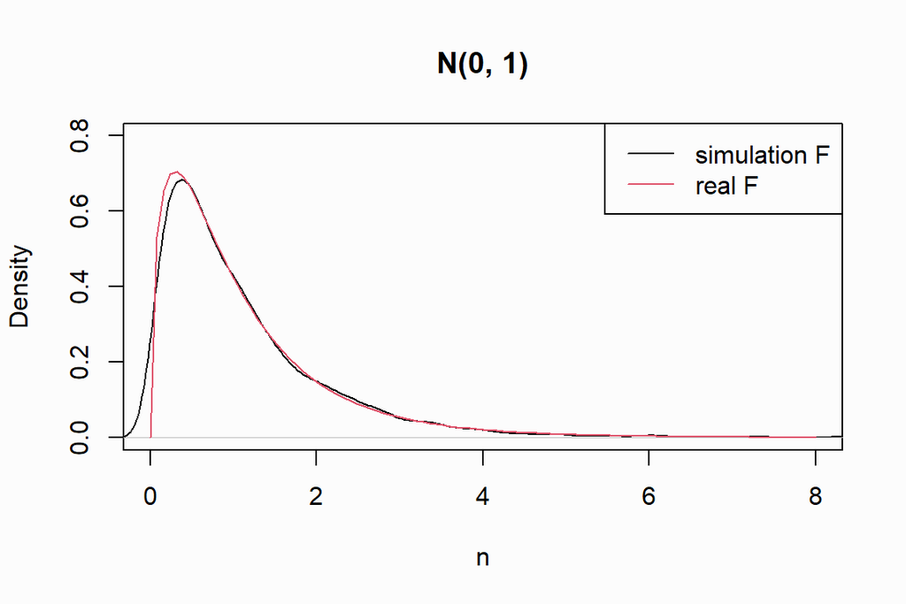

```r
B <- 5000 #重複實驗次數
f <- rep(NA, B)
t <- 0

for (i in 1:B){
  error <- rnorm(N, 0, 1)  #N=20
  obs <- mu + tau + error
  fit <- lm(obs~X1)
  anova <- anova(fit)
  f[i] <- anova$`F value`[1]
  if (anova$`Pr(>F)`[1]<=0.05) t <- t+1
}
par(bg="#fcfcfc")
plot(density(f), xlim=c(0,8),ylim=c(0.0,0.8), main="N(0, 1)", xlab="n")
curve(df(x, anova$Df[1], anova$Df[2]), col=2, add=T)
legend("topright", c("simulation F", "real F"), col=c(1,2), lty=1)
```

```r
t/B # type I error
```

```
## [1] 0.046
```

```r
anova
```

```
## Analysis of Variance Table
##
## Response: obs
##           Df  Sum Sq Mean Sq F value Pr(>F)
## X1         3  2.3591 0.78636  0.5955  0.627
## Residuals 16 21.1291 1.32057
```

```r
fit
```

```
##
## Call:
## lm(formula = obs ~ X1)
##
## Coefficients:
## (Intercept)          X11          X12          X13
##    616.8964       0.1986       0.4602      -0.2872
```

```r
summary(fit)
```

```
##
## Call:
## lm(formula = obs ~ X1)
##
## Residuals:
##      Min       1Q   Median       3Q      Max
## -1.90401 -0.78621  0.07595  0.40458  2.23841
##
## Coefficients:
##             Estimate Std. Error  t value Pr(>|t|)
## (Intercept) 616.8964     0.2570 2400.747   <2e-16 ***
## X11           0.1986     0.4451    0.446    0.661
## X12           0.4602     0.4451    1.034    0.317
## X13          -0.2872     0.4451   -0.645    0.528
## ---
## Signif. codes:  0 '***' 0.001 '**' 0.01 '*' 0.05 '.' 0.1 ' ' 1
##
## Residual standard error: 1.149 on 16 degrees of freedom
## Multiple R-squared:  0.1004, Adjusted R-squared:  -0.06823
## F-statistic: 0.5955 on 3 and 16 DF,  p-value: 0.627
```

## **Confidence Interval for Type I Error**

```r
ci_upper <- 0.05+1.96*sqrt(0.05*0.05/B)
ci_lower <- 0.05-1.96*sqrt(0.05*0.05/B)
ci_upper ; ci_lower
```

```
## [1] 0.05138593
```

```
## [1] 0.04861407
```

# **Poisson Distribution**

## lambda不變，控制樣本數

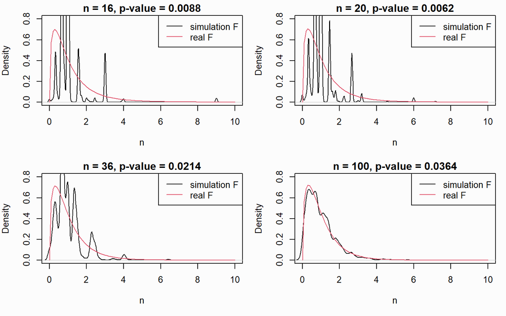

```r
par(bg="#fcfcfc", mfrow=c(2, 2), mar=c(5, 4, 1.5, 1))
N <- c(16, 20, 36, 100) #樣本數
lambda <- 0.1

for (k in 1:length(N)) {
  X1 <- design_matrix(N[k])
  f <- rep(NA, B)
  t <- 0
  tau <- rep(0, N[k])
  mu <- rep(3, N[k])
  for (i in 1:B){
    error <- rpois(N[k], lambda) - lambda
    obs <- mu + tau + error
    fit <- lm(obs~X1)
    anova <- anova(fit)
    f[i] <- anova$`F value`[1]
    if (anova$`Pr(>F)`[1]<=0.05) t <- t+1
  }
  plot(density(f), xlim=c(0,10), ylim=c(0,0.8), main=paste0("n = ",N[k],", p-value = ",round(t/B,4)), xlab="n")
  curve(df(x, anova$Df[1], anova$Df[2]), col=2, add=T)
  legend("topright", c("simulation F", "real F"), col=c(1,2), lty=1)
}
```

## 樣本數不變，控制lambda

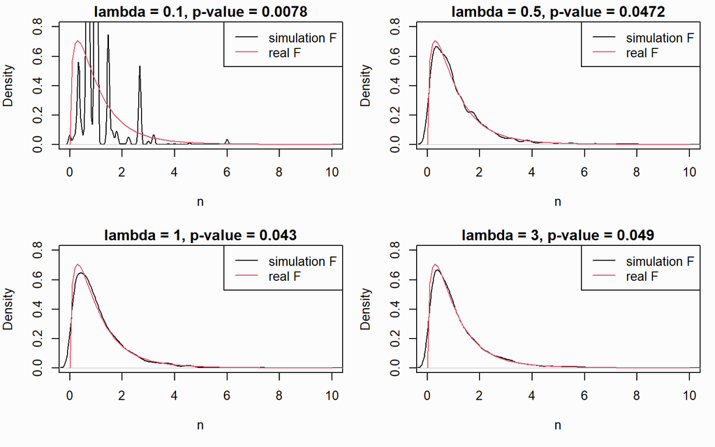

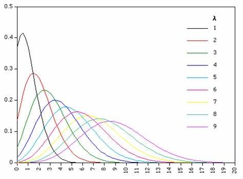

```r
par(bg="#fcfcfc", mfrow=c(2, 2), mar=c(5,4,1.5,1))
N <- 20
lambda <- c(0.1, 0.5, 1, 3)
p_value <- rep(NA, 4)

for (l in 1:length(lambda)) {
  X1 <- design_matrix(N)
  f <- rep(NA, B)
  t <- 0
  tau <- rep(0, N)
  mu <- rep(3, N)
  for (i in 1:B){
    e <- rpois(N, lambda[l]) - lambda[l]
    obs <- mu + tau + e
    fit <- lm(obs~X1)
    anova <- anova(fit)
    f[i] <- anova$`F value`[1]
    if (anova$`Pr(>F)`[1]<=0.05) t <- t+1
  }
  plot(density(f), xlim=c(0,10), ylim=c(0,0.8), main=paste0("lambda = ",lambda[l],", p-value = ",round(t/B,4)), xlab="n")
  curve(df(x, anova$Df[1], anova$Df[2]), col=2, add=T)
  legend("topright", c("simulation F", "real F"), col=c(1,2), lty=1)
}
```

Poisson Distribution 在 lambda 小的時候 right-skewed 的情況會比較明顯；大的時候會比較接近常態分配，模擬出來的情況會比較好

# **Binomial Distribution**

## 試驗次數和p不變，控制樣本數

### n=12, 20, 100, 2000 ; p=0.25, size=100

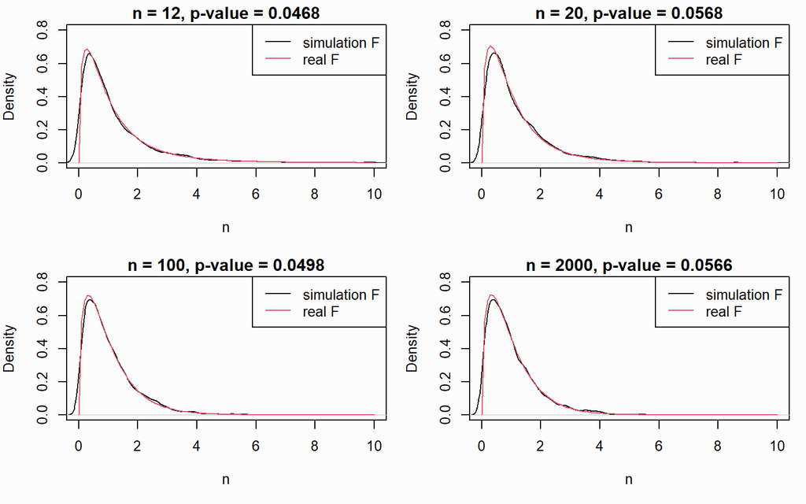

```r
N <- c(12, 20, 100, 2000) #樣本數
par(bg="#fcfcfc", mfrow=c(2, 2), mar=c(5, 4, 1.5, 1))
for (k in 1:length(N)){
  X1 <- design_matrix(N[k])
  f <- rep(NA, B)
  t <- 0
  tau <- rep(0, N[k])
  mu <- rep(3, N[k])
  for (i in 1:B){
    e <- rbinom(N[k], size=100, 0.25) - 25
    obs <- mu + tau + e
    fit <- lm(obs~X1)
    anova <- anova(fit)
    f[i] <- anova$`F value`[1]
    if (anova$`Pr(>F)`[1]<=0.05) t <- t+1
  }
  plot(density(f), main=paste0("n = ",N[k],", p-value = ",round(t/B,4)), xlim=c(0,10), ylim=c(0,0.8), xlab="n")
  curve(df(x, anova$Df[1], anova$Df[2]), col=2, add=T)
  legend("topright", c("simulation F", "real F"), col=c(1,2), lty=1.5)
}
```

### 改變實驗次數與機率

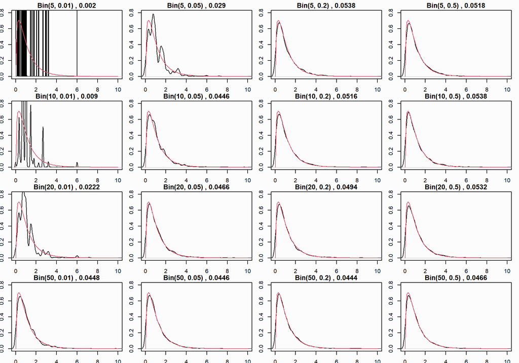

```r
N <- 20
n <- c(5, 10, 20, 50) #實驗次數
p <- c(0.01, 0.05, 0.2, 0.5) #機率
X1 <- design_matrix(N)
par(bg="#fcfcfc", mfrow=c(4, 4), mar=c(1.7, 1.7, 1.5, 1.1))
f <- rep(NA, B)
for(s in 1:length(n)){
  for (k in 1:length(p)) {
    t <- 0
    tau <- rep(0, N)
    mu <- rep(3, N)
    for (i in 1:B){
      e <- rbinom(N, n[s], p[k]) - n[s]*p[k]
      obs <- mu + tau + e
      fit <- lm(obs~X1)
      anova <- anova(fit)
      f[i] <- anova$`F value`[1]
      if (anova$`Pr(>F)`[1]<=0.05) t <- t+1
    }
    plot(density(f), main=paste0('Bin(', n[s],', ', p[k], ') , ', round(t/B,4)), xlim=c(0,10), ylim=c(0,0.8), xlab="n")
    curve(df(x, anova$Df[1], anova$Df[2]), col=2, add=T)
    #legend("topright", c("simulation F", "real F"), col=c(1,2), lty=1.5)
   }
}
```

```r
N <- 20
n <- c(1, 5, 10, 30)
p <- c(0.005, 0.01, 0.05, 0.1, 0.3)
D <- expand.grid(N, n, p)
colnames(D) <- c('N','n','p')
D <- cbind(D, 'type_I_error'=rep(NA, dim(D)[1]))

for (i in 1:dim(D)[1]) {
  X1 <- design_matrix(N)
  f <- rep(NA, B)
  t <- 0
  tau <- rep(0, D$N[i])
  mu <- rep(3, D$N[i])
  for (j in 1:B) {
    error <- rbinom(D$N[i], D$n[i], D$p[i]) - D$n[i]*D$p[i]
    obs <- mu + tau + error
    fit <- lm(obs~X1)
    anova <- anova(fit)
    f[j] <- anova$`F value`[1]
    if (!is.nan(anova$`F value`[1])){
      if (anova$`Pr(>F)`[1] <= 0.05) {t <- t+1}
    }
  }
  D$type_I_error[i] <- round(t/B, 4)
}
```

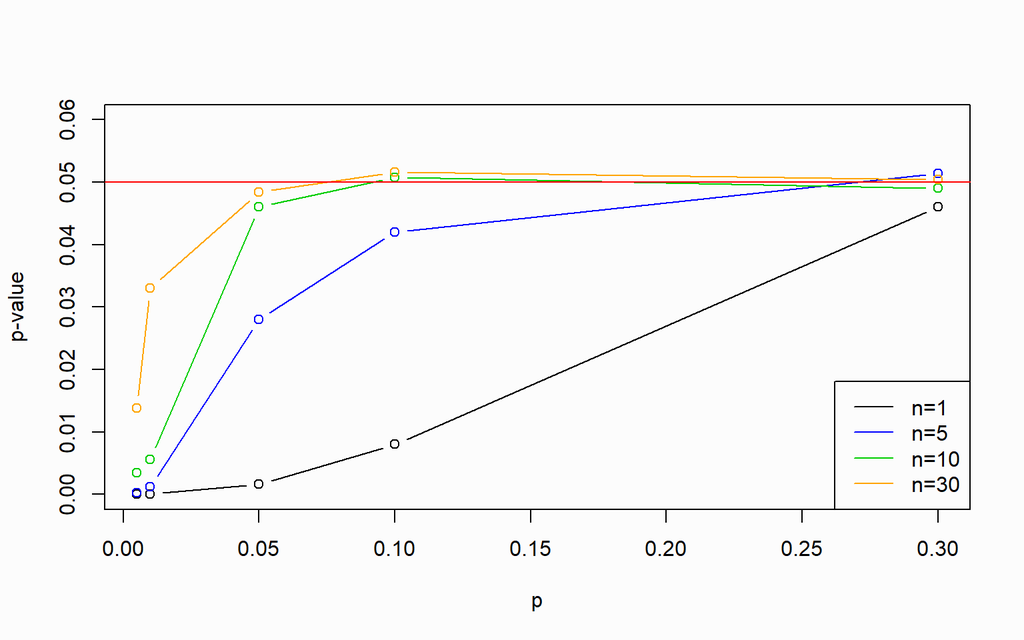

# **Gamma Distribution**

## 控制樣本數

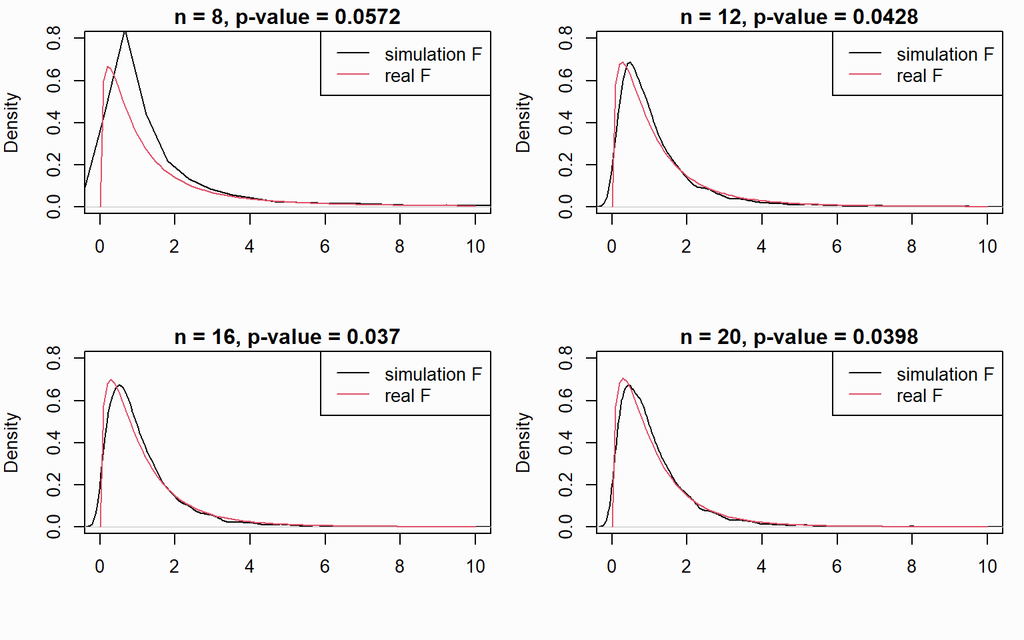

```r
#樣本數 = 8, 12, 16, 20
N <- c(8, 12, 16, 20)
alpha <- 1
beta <- 1
par(bg="#fcfcfc", mfrow=c(2, 2), mar=c(5, 4, 1.5, 1))

for (k in 1:length(N)) {
  X1 <- design_matrix(N[k])
  f <- rep(NA, B)
  t <- 0
  tau <- rep(0, N[k])
  mu <- rep(3, N[k])
  for (i in 1:B){
    e <- rgamma(N[k], alpha, beta) - alpha/beta
    obs <- mu + tau + e
    fit <- lm(obs~X1)
    anova <- anova(fit)
    f[i] <- anova$`F value`[1]
    if (anova$`Pr(>F)`[1]<=0.05) t <- t+1
  }
  plot(density(f), xlim=c(0,10), ylim=c(0,0.8), main=paste0("n = ",N[k],", p-value = ",round(t/B, 4)), xlab="")
  curve(df(x, anova$Df[1], anova$Df[2]), col=2, add=T)
  legend("topright", c("simulation F", "real F"), col=c(1,2), lty=1)
}
```

## 看 alpha, beta 如何影響 pdf 圖形(n=100)

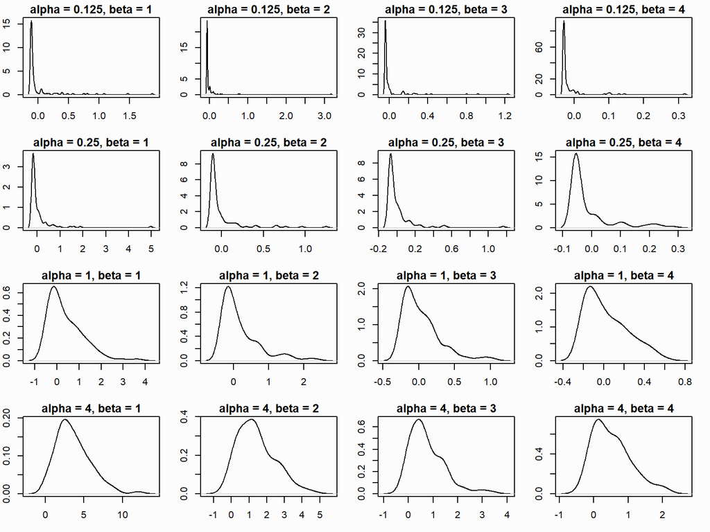

alpha 越大偏態越趨近於0（越對稱），觀察出Gamma分配的偏態係數$=2/\sqrt{\alpha}$的趨勢

## 調整 alpha

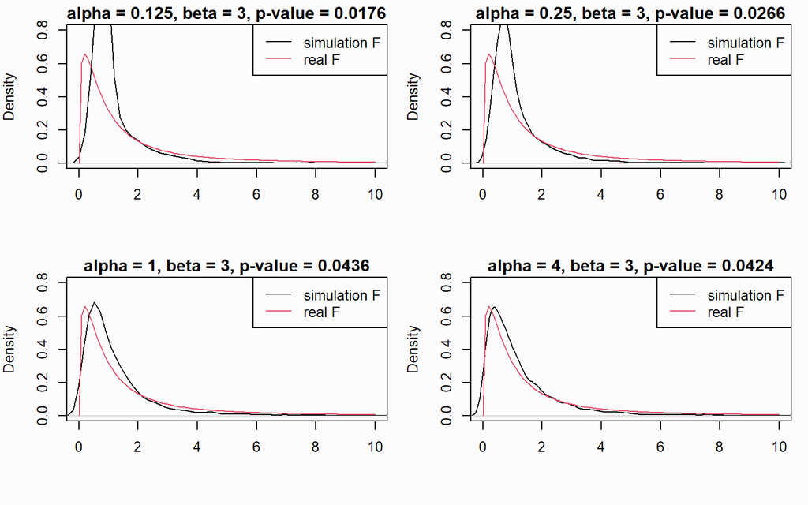

```r
par(bg="#fcfcfc", mfrow=c(2, 2), mar=c(5,4,1.5,1))
N <- 12
t <- 0
alpha <- c(1/8,1/4,1,4)
beta <- 3
for (a in 1:length(alpha)) {
  X1 <- design_matrix(N)
  f <- rep(NA, B)
  t <- 0
  for (i in 1:B){
    e <- rgamma(N, alpha[a], beta)-(alpha[a]/beta)
    tau <- rep(0, N)
    mu <- rep(3, N)
    obs <- mu + tau + e
    fit <- lm(obs~X1)
    anova <- anova(fit)
    f[i] <- anova$`F value`[1]
    if (anova$`Pr(>F)`[1]<=0.05) t <- t+1
  }
  plot(density(f), xlim=c(0,10), ylim=c(0,0.8), main=paste0("alpha = ",alpha[a],", beta = ",beta ,", p-value = ",round(t/B,4)), xlab="")
  curve(df(x, anova$Df[1], anova$Df[1]), col=2, add=T)
  legend("topright", c("simulation F", "real F"), col=c(1,2), lty=1)
}
```

-> 看圖可發現，固定beta之下，alpha越大，越趨近real F，且type-one error往0.05靠近

## 調整 beta

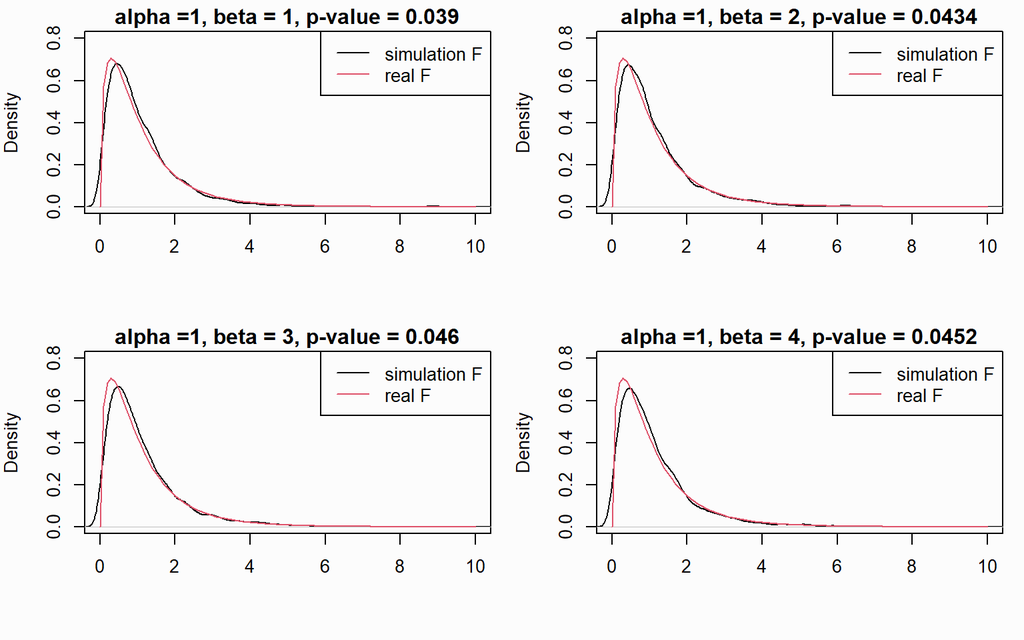

```r
par(bg="#fcfcfc", mfrow=c(2, 2), mar=c(5,4,1.5,1))
N <- 20
t <- 0
alpha <- 1
beta <- c(1,2,3,4)
for (b in 1:length(beta)) {
  X1 <- design_matrix(N)
  f <- rep(NA, B)
  t <- 0
  for (i in 1:B){
    e <- rgamma(N, alpha, beta[b])-(alpha/beta[b])
    tau <- rep(0, N)
    mu <- rep(3, N)
    obs <- mu + tau + e
    fit <- lm(obs~X1)
    anova <- anova(fit)
    f[i] <- anova$`F value`[1]
    if (anova$`Pr(>F)`[1]<=0.05) t <- t+1
  }
  plot(density(f), xlim=c(0,10), ylim=c(0,0.8), main=paste0("alpha =", alpha, ", beta = ",beta[b],", p-value = ",round(t/B,4)), xlab="")
  curve(df(x, anova$Df[1], anova$Df[2]), col=2, add=T)
  legend("topright", c("simulation F", "real F"), col=c(1,2), lty=1)
}
```

beta 對於 f 沒有什麼顯著的發現

綜合以上，由於Gamma分配的偏態係數為 $2/\sqrt{\alpha}$ ，因此在alpha越大時，skewness會越趨近於0（越對稱），此時type-one error也較靠近0.05

# **t Distribution**

## 控制樣本數

### n = 8, 12, 16, 20, 40

```r
N <- c(8, 12, 16, 20, 40)
p_value <- vector(mode="list",length=5)
for (k in 1:length(N)){
  X1 <- design_matrix(N[k])
  pp <- rep(NA, N[k]-1)
  for (df in 1:(N[k]-1)){
    t <- 0
    for (i in 1:B){
      e <- rt(N[k], df=df)
      tau <- rep(0, N[k])
      mu <- rep(3, N[k])
      obs <- mu + tau + e
      fit <- lm(obs~X1)
      anova <- anova(fit)
      if (anova$`Pr(>F)`[1]<=0.05) t <- t+1
    }
    pp[df] <- round(t/B,4)
  }
  p_value[[k]] <- pp
}
```

## 不同樣本數的 p-value 比較

### n=8

#### 在信賴區間的比例 0

| Df=1 | Df=2 | Df=3 | Df=4 | Df=5 | Df=6 | Df=7 |
| --- | --- | --- | --- | --- | --- | --- |
| 0.0252 | 0.0334 | 0.038 | 0.039 | 0.0384 | 0.046 | 0.0412 |

### n=12

#### 在信賴區間的比例 0.1818182

| Df=1 | Df=2 | Df=3 | Df=4 | Df=5 | Df=6 | Df=7 | Df=8 | Df=9 | Df=10 | Df=11 |
| --- | --- | --- | --- | --- | --- | --- | --- | --- | --- | --- |
| 0.0224 | 0.0294 | 0.0422 | 0.04 | 0.0388 | 0.0426 | 0.0462 | 0.0466 | 0.0436 | 0.0496 | 0.0498 |

### n=16

#### 在信賴區間的比例 0.2

| Df=1 | Df=2 | Df=3 | Df=4 | Df=5 | Df=6 | Df=7 | Df=8 | Df=9 | Df=10 |
| --- | --- | --- | --- | --- | --- | --- | --- | --- | --- |
| 0.0156 | 0.0322 | 0.034 | 0.0446 | 0.0506 | 0.0466 | 0.0494 | 0.0516 | 0.0422 | 0.0454 |

| Df=11 | Df=12 | Df=13 | Df=14 | Df=15 |
| --- | --- | --- | --- | --- |
| 0.0514 | 0.0516 | 0.0512 | 0.046 | 0.0516 |

### n=20

#### 在信賴區間的比例 0.1052632

| Df=1 | Df=2 | Df=3 | Df=4 | Df=5 | Df=6 | Df=7 | Df=8 | Df=9 | Df=10 |
| --- | --- | --- | --- | --- | --- | --- | --- | --- | --- |
| 0.0164 | 0.0332 | 0.0418 | 0.0428 | 0.0426 | 0.0478 | 0.0478 | 0.0486 | 0.048 | 0.0492 |

| Df=11 | Df=12 | Df=13 | Df=14 | Df=15 | Df=16 | Df=17 | Df=18 | Df=19 |
| --- | --- | --- | --- | --- | --- | --- | --- | --- |
| 0.042 | 0.0522 | 0.0516 | 0.0462 | 0.045 | 0.047 | 0.0502 | 0.047 | 0.0522 |

### n=40

#### 在信賴區間的比例 0.3333333

| Df=1 | Df=2 | Df=3 | Df=4 | Df=5 | Df=6 | Df=7 | Df=8 | Df=9 | Df=10 |
| --- | --- | --- | --- | --- | --- | --- | --- | --- | --- |
| 0.0154 | 0.0334 | 0.0396 | 0.0488 | 0.0496 | 0.0464 | 0.0492 | 0.041 | 0.0466 | 0.05 |

| Df=11 | Df=12 | Df=13 | Df=14 | Df=15 | Df=16 | Df=17 | Df=18 | Df=19 | Df=20 |
| --- | --- | --- | --- | --- | --- | --- | --- | --- | --- |
| 0.0436 | 0.0498 | 0.0506 | 0.0572 | 0.044 | 0.055 | 0.0504 | 0.0442 | 0.048 | 0.0472 |

| Df=21 | Df=22 | Df=23 | Df=24 | Df=25 | Df=26 | Df=27 | Df=28 | Df=29 | Df=30 |
| --- | --- | --- | --- | --- | --- | --- | --- | --- | --- |
| 0.0494 | 0.0484 | 0.0478 | 0.05 | 0.0506 | 0.0524 | 0.0536 | 0.0478 | 0.0482 | 0.0494 |

| Df=31 | Df=32 | Df=33 | Df=34 | Df=35 | Df=36 | Df=37 | Df=38 | Df=39 |
| --- | --- | --- | --- | --- | --- | --- | --- | --- |
| 0.0496 | 0.0514 | 0.0494 | 0.0562 | 0.0532 | 0.0524 | 0.0486 | 0.0552 | 0.0538 |

[figure not shown]

樣本數越大，越有機率涵蓋真正的type I error 值，而自由度不要太大也不要太小時，會越有可能越接近0.05